# El OCSA en 2026

Qué somos, qué venimos haciendo y lo que nos falta

Carlos Andrés Yanes Guerra

Director del OCSA, Universidad del Norte

noviembre 2026

## ¿Qué es el OCSA?

El Observatorio de Condiciones Socioeconómicas del Caribe Colombiano estudia cómo viven y trabajan las personas de la región, con datos rigurosos y en un lenguaje que todos entiendan.

**Investigamos**Informalidad, pobreza, desigualdad y mercado laboral con microdatos oficiales.

**Acompañamos**Tesis, estudiantes y entidades que necesitan evidencia para decidir.

**Abrimos los datos**Herramientas para que cualquiera consulte la información sin programar.

**Contamos**Blogs, cátedras y escuelas que llevan la evidencia a la conversación pública.

## Colombia crece, pero no formaliza

55,3% de los ocupados trabaja en la informalidad, unos 13,3 millones de personas (feb. 2026), aunque la economía creció 2,6% en 2025.

Crecer no basta. La economía avanza, pero más de la mitad de quienes trabajan sigue sin contrato ni protección.

Yanes (2026), *Revista Mi Pyme + Productiva*, ACOPI.

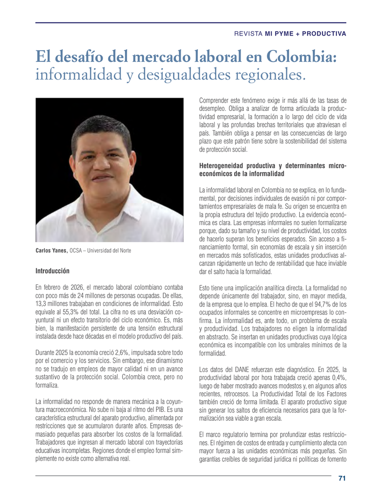

## Economía aplicada desde y para el Caribe

94,7% de los ocupados informales está en microempresas

La informalidad no es una mala decisión de las personas. Nace de empresas pequeñas y poco productivas, y en el Caribe pesa más.

Microdatos del DANE (GEIH, Encuesta de Micronegocios y Estadísticas Vitales).

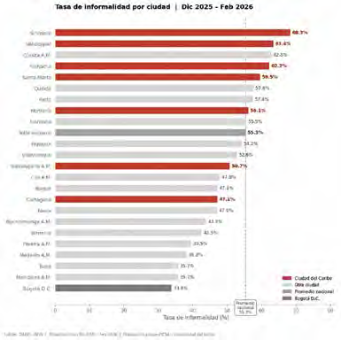

Tasa de informalidad por ciudad, dic. 2025 - feb. 2026. En rojo, las ciudades del Caribe.

## La asistencia técnica como fuente de conocimiento

Acompañar investigaciones también nos devuelve conocimiento: dos tesis de maestría nos dejaron dos lecciones sobre la informalidad.

[figure not shown]

[figure not shown]

Tesis de Maestría en Economía de Adriana Restrepo (2025) y Gleirys Amaya (2026), Universidad del Norte.

## La formalización es una transición

Formalizarse es un camino por etapas. Los negocios avanzan a medida que crecen, y un Estado local que funciona bien les ayuda a dar el paso.

Restrepo (2025), tesis de Maestría en Economía, Uninorte. EMICRON, GEIH e Índice de Desempeño Institucional, 2024.

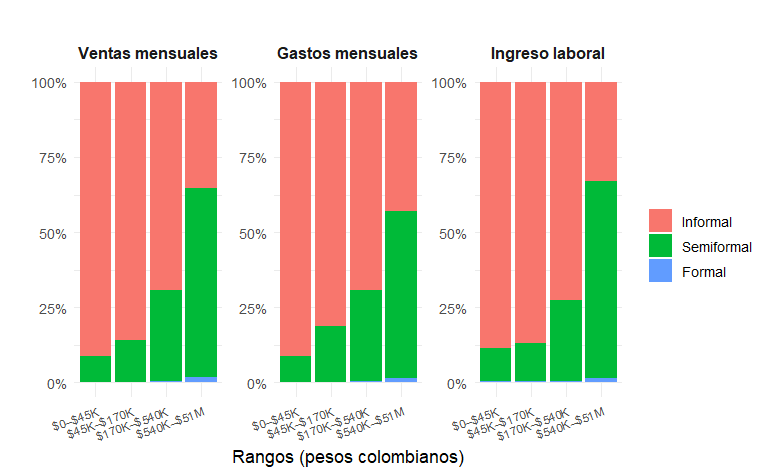

A más ventas, gastos e ingresos, menos microempresas informales y más semiformales.

## La protección social también mueve decisiones

18-29 años el único grupo de edad en que la relación es significativa

Dar salud gratis a quien no cotiza hace menos atractiva la formalidad, sobre todo para los jóvenes que buscan su primer empleo.

Amaya (2026), tesis de Maestría en Economía, Uninorte. Pseudo-panel GEIH 2018-2025.

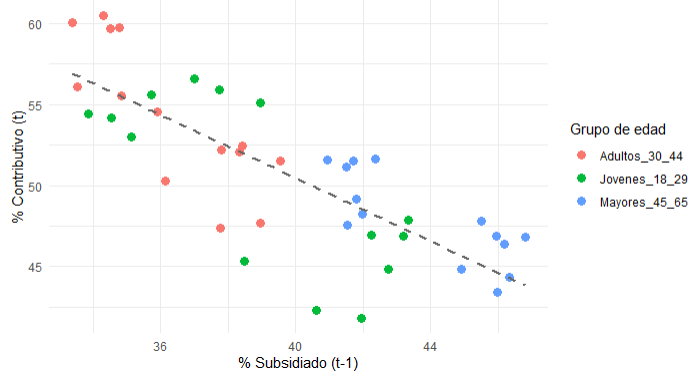

Más afiliados al régimen subsidiado un año, menos afiliados al contributivo el siguiente.

## Escuela de Verano CLACSO

0,551 Gini de Colombia en 2024, frente a 0,553 en 2023

Colombia sigue entre los países más desiguales del mundo, y formalizar el empleo es también una forma de reducir esa brecha.

Universidad del Norte y CLACSO, 14 al 16 de julio de 2026, Barranquilla.

[figure not shown]

## Escuela de Verano: desigualdad e informalidad

-14% caería el Gini de la región con una formalización laboral plena (CEPAL)

Formalizar el empleo también reduce la desigualdad: son dos caras del mismo problema.

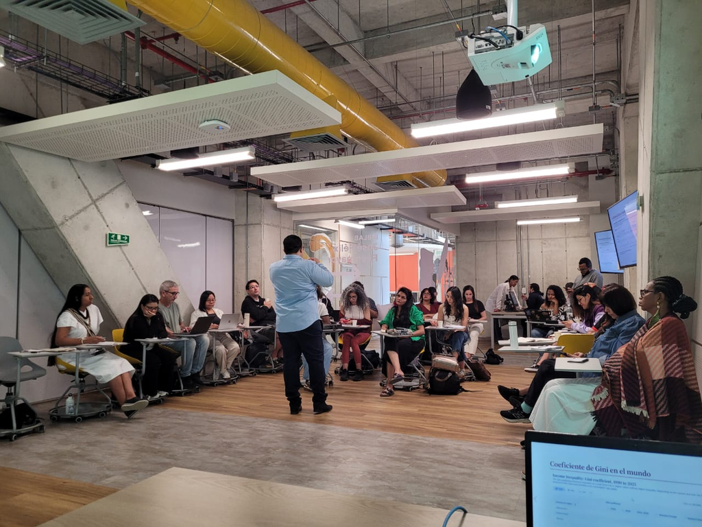

## Cátedra Barranquilla y los jóvenes

25,8% de los niños y jóvenes del Atlántico cursa grados por debajo de su edad (rezago escolar)

Crecer no basta si los jóvenes llegan atrasados. Con menos estudio, el mercado laboral los empuja a la informalidad.

OCSA, Cátedra Barranquilla, a partir de DANE (pobreza multidimensional, Atlántico).

[figure not shown]

## Cátedra Barranquilla: la informalidad, otra vez

71-76% de los **hogares** del Atlántico tiene al menos un ocupado en la informalidad, según se mida en la cabecera urbana o fuera del Área Metropolitana

Siete de cada diez hogares del Atlántico viven con la informalidad dentro de casa: es la carencia más extendida.

OCSA, Cátedra Barranquilla, a partir de DANE, pobreza multidimensional (privación por trabajo informal).

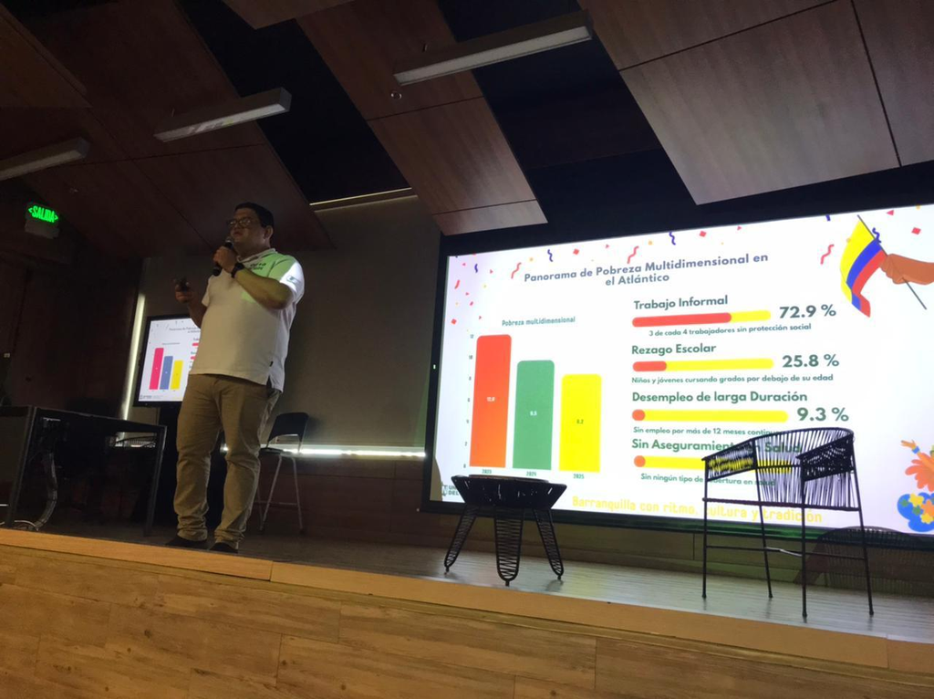

## La GEIH al alcance de todos

19 años de la GEIH (2007-2025) para consultar con unos pocos clics

Abrir los datos también es crear conocimiento. Cualquier persona puede consultar la GEIH sin escribir una línea de código.

Explorador GEIH del OCSA, desarrollado por Juan Camilo Pinedo.

ocsa-explorador-geih.streamlit.app

[figure not shown]

## Contamos lo que investigamos

+20 blogs publicados sobre informalidad, pobreza, desigualdad y mercado laboral en el Caribe

Lo que investigamos lo contamos en lenguaje claro, para que llegue a la conversación pública de la región.

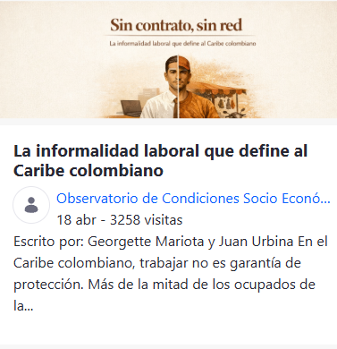

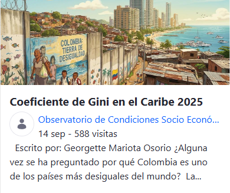

[figure not shown]

Escanea para leer los blogs del OCSA

## La salud, nuestro siguiente paso

2.473 mujeres fallecidas por cáncer de mama en el Caribe continental, 2022-2024

Cómo se trabaja define cómo se accede a la salud, y por eso queremos crecer hacia allá.

OCSA, a partir de DANE, Estadísticas Vitales.

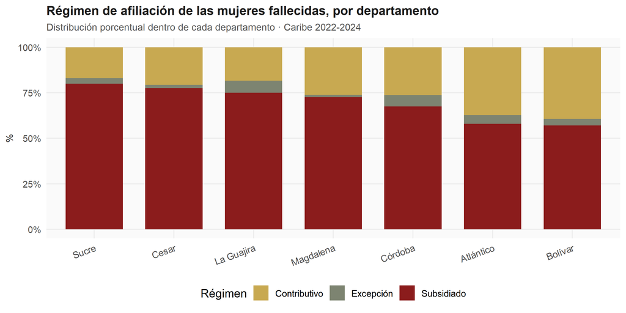

Régimen de afiliación de las mujeres fallecidas, por departamento: en todos predomina el subsidiado.

## Lo que nos falta

- Consolidar la línea de salud, empezando por el costo de la atención del cáncer de mama según régimen.
- Más alianzas con el sector público, los gremios y otras universidades para que la evidencia llegue a las decisiones.
- Financiación estable para sostener proyectos de largo plazo.
- Más estudiantes y jóvenes investigadores trabajando con nosotros.
- Llevar el Explorador GEIH y el blog a mucha más gente.

## Cierre

Distintas preguntas, un mismo hilo.

Diversificar sin dispersarnos.

## Gracias

Gracias

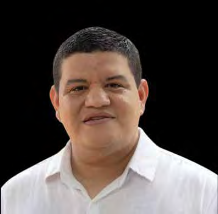

Carlos Andrés Yanes Guerra

Director del OCSA y profesor asistente del Departamento de Economía, Universidad del Norte

Microeconomía, econometría y ciencia de datos

cayanes@uninorte.edu.co

[X: @Keynes37](https://x.com/keynes37)

[GitHub: keynes37](https://github.com/keynes37)

[Google Scholar](https://scholar.google.com/citations?user=NlFSQDwAAAAJ&hl=es)

[LinkedIn](https://www.linkedin.com/in/carlos-andres-yanes-guerra-0026bb31/)

**OCSA**: ocsa@uninorte.edu.co, uninorte.edu.co/web/ocsa, Bloque D, segundo piso